# OCCE Fact Sheet

## HVAC and Surface Temperature

Literature has found associations between exposure to extreme heat with greater risks of cardiovascular mortality. Extreme heat is also a risk factor associated with hospitalization for cardiovascular diseases. In Miami-Dade county, alongside poor socioeconomic variables (age of home and household income) low rates of ownership of air conditioners (AC) and extreme surface temperatures present real danger to disadvantaged neighborhoods.

### AC Ownership by Surface Temperature

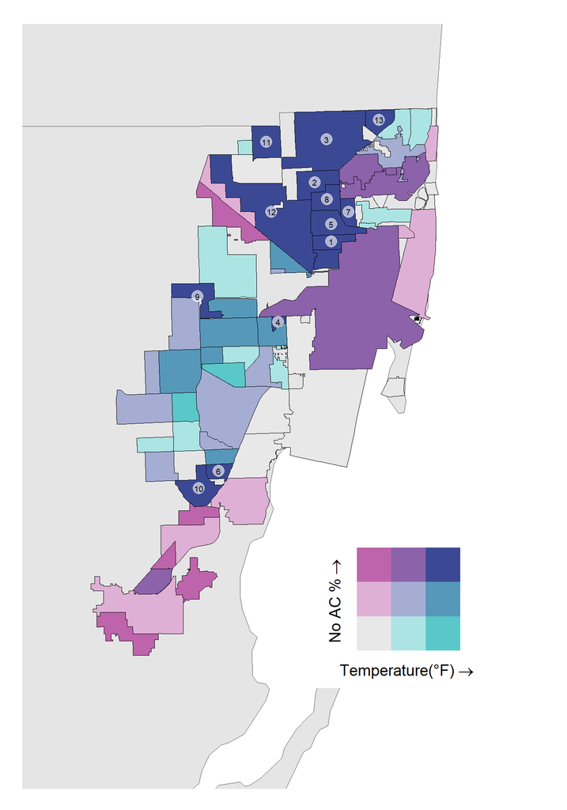

HVAC and Temp

| Place | No AC % | Temperature (°F) |
| --- | --- | --- |
| Gladeview | 49.43 | 104.12 |
| Opa-locka | 47.58 | 102.10 |
| Miami Gardens | 44.37 | 103.22 |
| West Miami | 43.41 | 103.60 |
| West Little River | 44.95 | 102.82 |
| West Perrine | 44.42 | 102.81 |
| Pinewood | 46.42 | 101.62 |
| Westview | 43.56 | 102.30 |
| Sweetwater | 44.46 | 101.77 |
| South Miami Heights | 43.49 | 102.22 |
| Country Club | 44.85 | 101.19 |
| Hialeah | 43.58 | 101.64 |
| Ives Estates | 44.34 | 101.25 |

AC is Percent of Homes That Do Not Own Any Type of Air Conditioning

## Overview Table - HVAC and Temperature

```r
table1
```

HVAC and Temp

|  | Place | No AC % | Temperature (°F) | Decade Home Built | Household Income |
| --- | --- | --- | --- | --- | --- |
| ① | Gladeview | 49.43 | 104.12 | 1960s | $50,000 |
| ② | Opa-locka | 47.58 | 102.10 | 1970s | ≤$30,000 |
| ③ | Miami Gardens | 44.37 | 103.22 | 1970s | $50,000 |
| ④ | West Miami | 43.41 | 103.60 | 1960s | $50,000 |
| ⑤ | West Little River | 44.95 | 102.82 | 1960s | $50,000 |
| ⑥ | West Perrine | 44.42 | 102.81 | 1980s | $50,000 |
| ⑦ | Pinewood | 46.42 | 101.62 | 1970s | $50,000 |
| ⑧ | Westview | 43.56 | 102.30 | 1970s | $50,000 |
| ⑨ | Sweetwater | 44.46 | 101.77 | 1980s | $50,000 |
| ⑩ | South Miami Heights | 43.49 | 102.22 | 1990s | $50,000 |
| ⑪ | Country Club | 44.85 | 101.19 | 1990s | $70,000 |
| ⑫ | Hialeah | 43.58 | 101.64 | 1980s | $50,000 |
| ⑬ | Ives Estates | 44.34 | 101.25 | 1980s | $70,000 |

AC is Percent of Homes That Do Not Own Any Type of Air Conditioning

## Cardiovascular Health, HVAC, and Temperature

High BP is High Blood Pressure. COPD is Chronic Obstructive Pulmonary Disease. Heart Disease is Coronary Heart Disease.

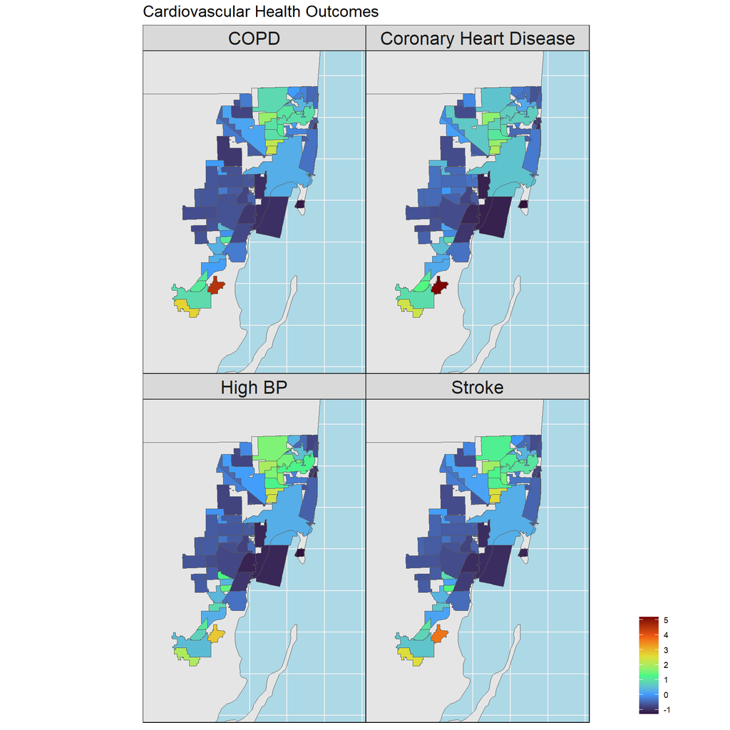

```r
plot_cardiovascular
```

```r
table5
```

Cardivascular Health, HVAC, and Temperature

|  | Place | No AC % | Temperature (°F) | Decade Home Built | Household Income | Coronary Heart Disease | Stroke | COPD | High Blood Pressure |
| --- | --- | --- | --- | --- | --- | --- | --- | --- | --- |
| ① | Gladeview | 49.43 | 104.12 | 1960s | $50,000 | 8.2 | 6.4 | 11.0 | 44.3 |
| ② | Opa-locka | 47.58 | 102.10 | 1970s | ≤$30,000 | 8.1 | 5.6 | 10.1 | 42.0 |
| ③ | Miami Gardens | 44.37 | 103.22 | 1970s | $50,000 | 6.5 | 4.7 | 7.9 | 39.8 |
| ④ | West Miami | 43.41 | 103.60 | 1960s | $50,000 | 5.4 | 2.5 | 4.6 | 27.3 |
| ⑤ | West Little River | 44.95 | 102.82 | 1960s | $50,000 | 7.2 | 4.7 | 8.1 | 37.7 |
| ⑥ | West Perrine | 44.42 | 102.81 | 1980s | $50,000 | 6.9 | 4.9 | 8.5 | 38.8 |
| ⑦ | Pinewood | 46.42 | 101.62 | 1970s | $50,000 | 7.0 | 5.1 | 8.6 | 41.0 |
| ⑧ | Westview | 43.56 | 102.30 | 1970s | $50,000 | 6.8 | 4.8 | 8.2 | 39.8 |
| ⑨ | Sweetwater | 44.46 | 101.77 | 1980s | $50,000 | 6.3 | 3.2 | 5.9 | 29.8 |
| ⑩ | South Miami Heights | 43.49 | 102.22 | 1990s | $50,000 | 6.4 | 3.6 | 6.6 | 32.5 |
| ⑪ | Country Club | 44.85 | 101.19 | 1990s | $70,000 | 5.5 | 2.9 | 5.2 | 29.2 |
| ⑫ | Hialeah | 43.58 | 101.64 | 1980s | $50,000 | 6.6 | 3.3 | 6.2 | 30.4 |
| ⑬ | Ives Estates | 44.34 | 101.25 | 1980s | $70,000 | 5.3 | 3.1 | 5.9 | 32.3 |

AC is Percent of Homes That Do Not Own Any Type of Air Conditioning. COPD is Chronic obstructive pulmonary disease among adults. All cardiovascular outcomes collected from adults >=18 years

## Health and Table Scores Analysis

Table Score (The sum of Mean Temperature and No AC Ownership/2) by row sums of Cardiovascular Health.

```
Call:
lm(formula = health_score ~ table_score, data = places_data_table_regressions)

Residuals:
    Min      1Q  Median      3Q     Max
-12.475  -5.994  -2.027   5.535  36.894

Coefficients:
            Estimate Std. Error t value Pr(>|t|)
(Intercept) -67.0597    19.8020  -3.387  0.00118 **
table_score   0.9518     0.1681   5.663 3.26e-07 ***
---
Signif. codes:  0 '***' 0.001 '**' 0.01 '*' 0.05 '.' 0.1 ' ' 1

Residual standard error: 9.09 on 68 degrees of freedom
Multiple R-squared:  0.3205,    Adjusted R-squared:  0.3105
F-statistic: 32.07 on 1 and 68 DF,  p-value: 3.262e-07
```

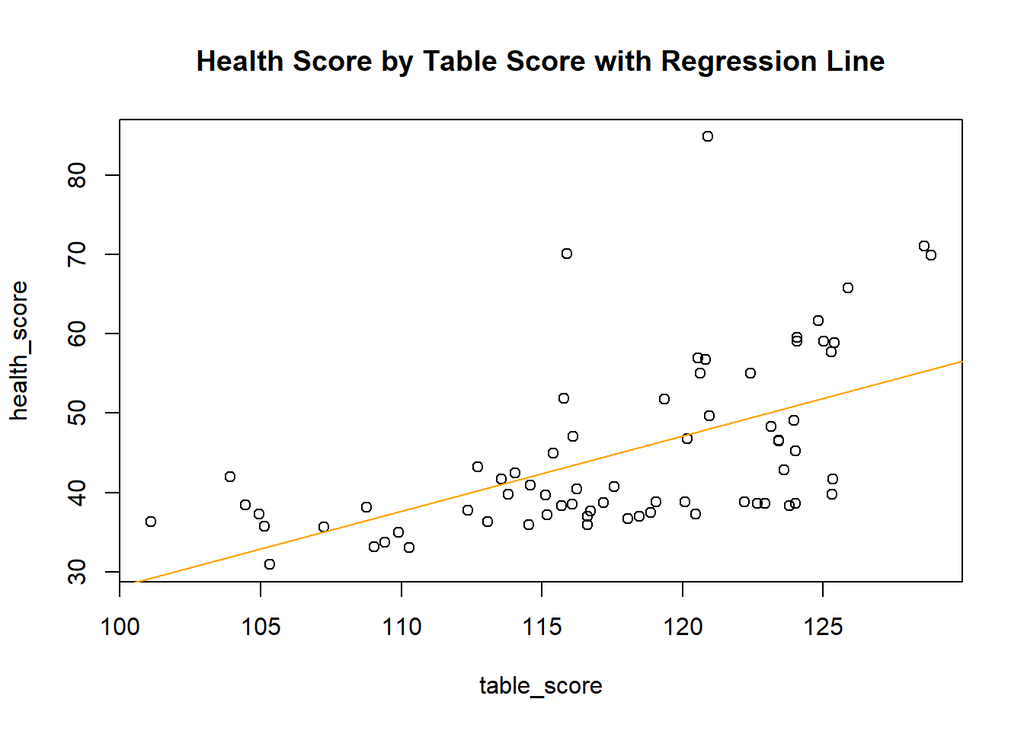

## Data Sources

Air Conditioning - Consumer Market Report Data from MRI Simmons. Calculated using consumption rate and counts.

Surface Temperature - ESRI

Socioeconomic Status and Age of Home - American Community Survey

## Citations

Bunker, A., Wildenhain, J., Vandenbergh, A., Henschke, N., Rocklöv, J., Hajat, S., & Sauerborn, R. (2016). Effects of Air Temperature on Climate-Sensitive Mortality and Morbidity Outcomes in the Elderly; a Systematic Review and Meta-analysis of Epidemiological Evidence. EBioMedicine, 6, 258–268. https://doi.org/10.1016/j.ebiom.2016.02.034

Chaseling, G. K., Iglesies-Grau, J., Juneau, M., Nigam, A., Kaiser, D., & Gagnon, D. (2021). Extreme Heat and Cardiovascular Health: What a Cardiovascular Health Professional Should Know. Canadian Journal of Cardiology, 37(11), 1828–1836. https://doi.org/10.1016/j.cjca.2021.08.008

Cheng, J., Xu, Z., Bambrick, H., Prescott, V., Wang, N., Zhang, Y., Su, H., Tong, S., & Hu, W. (2019). Cardiorespiratory effects of heatwaves: A systematic review and meta-analysis of global epidemiological evidence. Environmental Research, 177, 108610. https://doi.org/10.1016/j.envres.2019.108610 ```